# Supervised Learning - Foundations Project: ReCell

### TEST FOR LINEARITY AND INDEPENDENCE

- We will test for linearity and independence by making a plot of fitted values vs residuals and checking for patterns.
- If there is no pattern, then we say the model is linear and residuals are independent.
- Otherwise, the model is showing signs of non-linearity and residuals are not independent.

```python
# let us create a dataframe with actual, fitted and residual values
df_pred = pd.DataFrame()

df_pred["Actual Values"] = y_train  # actual values
df_pred["Fitted Values"] = olsmodel2.fittedvalues  # predicted values
df_pred["Residuals"] = olsmodel2.resid  # residuals

df_pred.head()
```

|  | Actual Values | Fitted Values | Residuals |
| --- | --- | --- | --- |
| 3026 | 4.087488 | 3.800785 | 0.286703 |
| 1525 | 4.448399 | 4.671627 | -0.223227 |
| 1128 | 4.315353 | 4.312365 | 0.002987 |
| 3003 | 4.282068 | 4.203344 | 0.078724 |
| 2907 | 4.456438 | 4.494569 | -0.038130 |

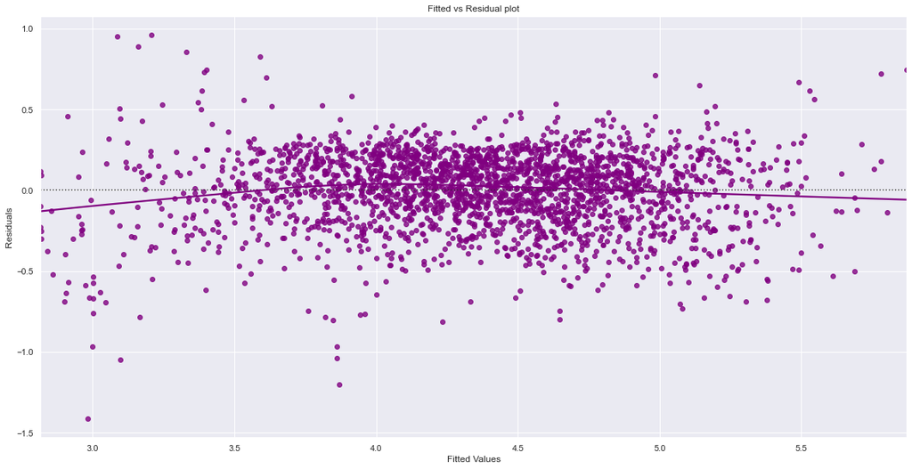

```python
# let's plot the fitted values vs residuals

sns.residplot(
    data=df_pred, x="Fitted Values", y="Residuals", color="purple", lowess=True
)
plt.xlabel("Fitted Values")
plt.ylabel("Residuals")
plt.title("Fitted vs Residual plot")
plt.show()
```

**Observations:**

- The scatter plot shows the distribution of residuals (errors) vs fitted values (predicted values).
- There is no pattern in the plot above. Hence, the assumptions of linearity and independence are satisfied

### TEST FOR NORMALITY

- We will test for normality by checking the distribution of residuals, by checking the Q-Q plot of residuals, and by using the Shapiro-Wilk test.
- If the residuals follow a normal distribution, they will make a straight line plot, otherwise not.
- If the p-value of the Shapiro-Wilk test is greater than 0.05, we can say the residuals are normally distributed.

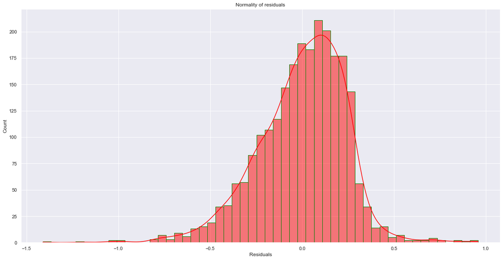

```python
sns.histplot(data=df_pred,x='Residuals',kde=True,color='red',edgecolor='green') ## Writing the code to plot the distribution of residuals
plt.title("Normality of residuals")
plt.show()
```

**Observations:**

- The histogram of residuals does have a bell shape.
- Let's check the Q-Q plot.

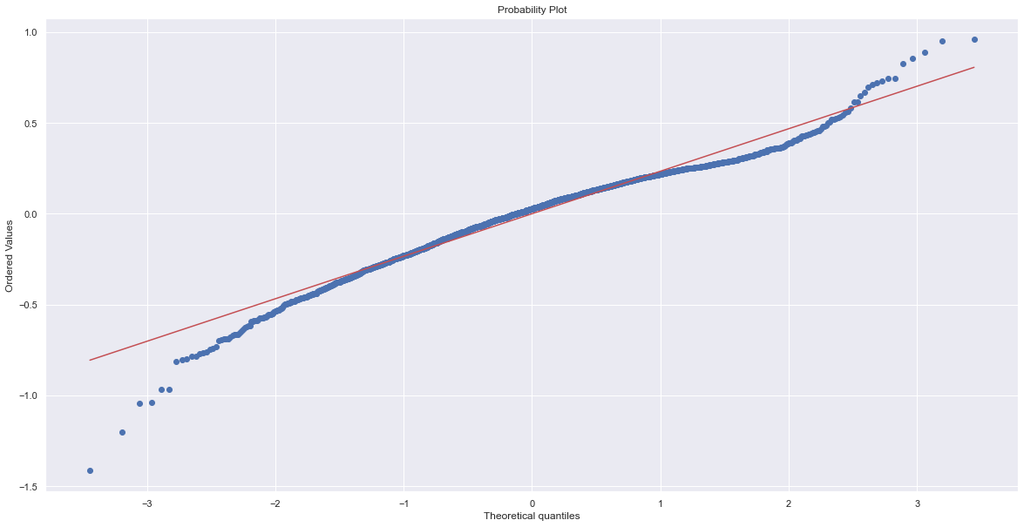

```python
import pylab
import scipy.stats as stats

stats.probplot(df_pred['Residuals'], dist="norm", plot=pylab) ## Writing the code check Q-Q plot
plt.show()
```

**Observations:**

- The residuals more or less follow a straight line except for the tails.
- Let's us see the results of the Shapiro-Wilk test.

```python
stats.shapiro(df_pred['Residuals']) ## Writing the code to apply the Shapiro-Wilks test
```

```
ShapiroResult(statistic=0.9711180329322815, pvalue=1.1404088285366056e-21)
```

**Observations:**

- Since p-value < 0.05, the residuals are not normal as per the Shapiro-Wilk test.
- Strictly speaking, the residuals are not normal.
- However, as an approximation, we can accept this distribution as close to being normal.
- So, the assumption is satisfied.

### TEST FOR HOMOSCEDASTICITY

- We will test for homoscedasticity by using the goldfeldquandt test.
- If we get a p-value greater than 0.05, we can say that the residuals are homoscedastic. Otherwise, they are heteroscedastic

```python
import statsmodels.stats.api as sms
from statsmodels.compat import lzip

name = ["F statistic", "p-value"]
test = sms.het_goldfeldquandt(df_pred["Residuals"], x_train3) ## Writing the code with the right train data to apply the Goldfeldquandt test
lzip(name, test)
```

```
[('F statistic', 1.0389346080820283), ('p-value', 0.2543034862552727)]
```

**Observations:**

- Since p-value > 0.05, we can say that the residuals are homoscedastic. So, this assumption is satisfied.

**Now that we have checked all the assumptions of linear regression and they are satisfied, let's go ahead with prediction.**

```python
# predictions on the test set
pred = olsmodel2.predict(x_test3)

df_pred_test = pd.DataFrame({"Actual": y_test, "Predicted": pred})
df_pred_test.sample(10, random_state=1)
```

|  | Actual | Predicted |
| --- | --- | --- |
| 1995 | 4.566741 | 4.396767 |
| 2341 | 3.696103 | 3.946634 |
| 1913 | 3.592093 | 3.715304 |
| 688 | 4.306495 | 4.143544 |
| 650 | 4.522115 | 5.126232 |
| 2291 | 4.259294 | 4.404316 |
| 40 | 4.997685 | 5.291358 |
| 1884 | 3.875359 | 4.070102 |
| 2538 | 4.206631 | 3.980933 |
| 45 | 5.380450 | 5.387768 |

- We can observe here that our model has returned pretty good prediction results, and the actual and predicted values are comparable.
- We can also visualize comparison result as a bar graph for a sample of 25 records

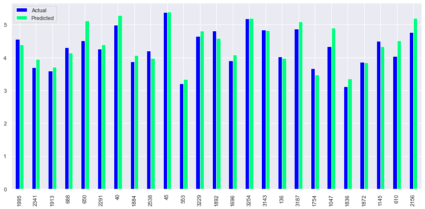

```python
df3 = df_pred_test.sample(25, random_state=1)
df3.plot(kind="bar", figsize=(15, 7),colormap='winter')
plt.show()
```

## Final Model Summary

```python
olsmodel_final = sm.OLS(y_train, x_train3).fit() ## Writing the code to fit the final model
print(olsmodel_final.summary())
```

```
                              OLS Regression Results
=================================================================================
Dep. Variable:     normalized_used_price   R-squared:                       0.835
Model:                               OLS   Adj. R-squared:                  0.834
Method:                    Least Squares   F-statistic:                     1350.
Date:                   Fri, 26 May 2023   Prob (F-statistic):               0.00
Time:                           10:28:28   Log-Likelihood:                 46.606
No. Observations:                   2417   AIC:                            -73.21
Df Residuals:                       2407   BIC:                            -15.31
Df Model:                              9
Covariance Type:               nonrobust
========================================================================================
                           coef    std err          t      P>|t|      [0.025      0.975]
----------------------------------------------------------------------------------------
const                   -0.0826      0.157     -0.528      0.598      -0.390       0.224
screen_size              0.0417      0.003     11.912      0.000       0.035       0.049
main_camera_mp           0.0213      0.002     13.825      0.000       0.018       0.024
selfie_camera_mp         0.0173      0.002     11.335      0.000       0.014       0.020
int_memory               0.0004      0.000      2.320      0.020    6.24e-05       0.001
ram                      0.0194      0.004      4.372      0.000       0.011       0.028
normalized_new_price     0.4056      0.011     36.826      0.000       0.384       0.427
weight_log               0.2612      0.038      6.814      0.000       0.186       0.336
os_Others               -0.0672      0.028     -2.399      0.017      -0.122      -0.012
4g_yes                   0.0432      0.014      3.101      0.002       0.016       0.070
==============================================================================
Omnibus:                      217.210   Durbin-Watson:                   1.936
Prob(Omnibus):                  0.000   Jarque-Bera (JB):              431.648
Skew:                          -0.589   Prob(JB):                     1.86e-94
Kurtosis:                       4.702   Cond. No.                     2.04e+03
==============================================================================

Notes:
[1] Standard Errors assume that the covariance matrix of the errors is correctly specified.
[2] The condition number is large, 2.04e+03. This might indicate that there are
strong multicollinearity or other numerical problems.
```

```python
# checking model performance on train set (seen 70% data)
print("Training Performance\n")
olsmodel_final_train_perf = model_performance_regression(olsmodel_final, x_train3, y_train) ## Writing the code to check the performance on train data
olsmodel_final_train_perf
```

```
Training Performance
```

|  | RMSE | MAE | R-squared | Adj. R-squared | MAPE |
| --- | --- | --- | --- | --- | --- |
| 0 | 0.23735 | 0.183576 | 0.834647 | 0.83396 | 4.424958 |

```python
# checking model performance on test set (seen 30% data)
print("Test Performance\n")
olsmodel_final_test_perf = model_performance_regression(olsmodel_final, x_test3, y_test) ## Writing the code to check performance on test data
olsmodel_final_test_perf
```

```
Test Performance
```

|  | RMSE | MAE | R-squared | Adj. R-squared | MAPE |
| --- | --- | --- | --- | --- | --- |
| 0 | 0.244273 | 0.188165 | 0.834565 | 0.832952 | 4.607551 |

#### Summary

- The model is able to explain ~83% of the variation in the data, which is very good.
- The train and test RMSE and MAE are low and comparable. So, our model is not suffering from overfitting.
- The Mean Absolute Percentage Error(MAPE) on the test set suggests we can predict the used devices prices within 4.6% error which is good because it is a low value
- Hence, we can conclude the model olsmod2 is good for prediction as well as inference purposes.

## Actionable Insights and Recommendations

  In summary therefore, the factors that significantly influence the price of refurbished devices in the market are as listed as below; - Size of the screen of the devices - Main camera mega pixels - selfie camera pixels - internal memory - RAM of the devices - Price of the similar new device - weight of the devices - Whether the device is a 4G or not - Operating system

### Key Take Away

- Since retailers usually run checks repair used phones to meet a certain standard in the refurbished market, factors like number of days the device has been used, battery and years since release of the device do not show significant impact on the price of the refurbished device, hence Recell should not worry about those factors a lot. As long as the device is repaired, it will get market.